# Project 2: TMDb - The Movie Database - Data Analysis Case Study

- Introduction
- Data Wrangling
- Exploratory Data Analysis
- Conclusions

## Introduction

The data set to be analysed contains roughly 10,800 movies from 1960 to 2015 collected from TMDb, The Movie Database. The data set has 21 columns including cast, director, user rating, genres, and revenue. The report is a partial fulfillment for the Data Analyst Nanodegree Program offered by Udacity. In this report, The fundamental data analysis process will be followed, namely data wrangling and exploratory data analysis (EDA). Five research questions are posed and their answers will be explored:

1. Who are the most popular 50 actors/actresses?
2. Which genres are most popular?
3. Which month released the most movies?
4. Is budget correlated with revenue?
5. What are the features related to high revenue?

To start, we can first import the libraries, set the visualization inline, and the theme at 'darkgrid'.

```python
# import libraries
import numpy as np
import pandas as pd
import matplotlib.pyplot as plt
import seaborn as sns
from scipy import stats
from datetime import datetime

# set visualization properties
%matplotlib inline
sns.set_theme(style='darkgrid')
```

## Data Wrangling

First of all, the data set will be loaded into a pandas dataframe. Then we will explore its general structure and properties, like missing data, duplicated rows, and invalid data types. Next, we will explore the tidiness of the data, investigate any invalid data values or outliers from examining the descriptive statistics. We also need to distinguish which features to keep for our analysis.

In the following steps, we will clean the data set. In the meanwhile, keep as much available information as possible. We will convert data types, drop unnecessary columns, remove missing values, replace data values and create subsets of dataframes to better fit our analysis.

### General Properties

Load the data set into a dataframe df.

```python
df = pd.read_csv('tmdb-movies.csv')
```

Look at its size.

```python
df.shape
```

```
(10866, 21)
```

Sneak peek into df.

```python
df.head()
```

|  | id | imdb_id | popularity | budget | revenue | original_title | cast | homepage | director | tagline | ... | overview | runtime | genres | production_companies | release_date | vote_count | vote_average | release_year | budget_adj | revenue_adj |
| --- | --- | --- | --- | --- | --- | --- | --- | --- | --- | --- | --- | --- | --- | --- | --- | --- | --- | --- | --- | --- | --- |
| 0 | 135397 | tt0369610 | 32.985763 | 150000000 | 1513528810 | Jurassic World | Chris Pratt\|Bryce Dallas Howard\|Irrfan Khan\|Vi... | http://www.jurassicworld.com/ | Colin Trevorrow | The park is open. | ... | Twenty-two years after the events of Jurassic ... | 124 | Action\|Adventure\|Science Fiction\|Thriller | Universal Studios\|Amblin Entertainment\|Legenda... | 6/9/15 | 5562 | 6.5 | 2015 | 1.379999e+08 | 1.392446e+09 |
| 1 | 76341 | tt1392190 | 28.419936 | 150000000 | 378436354 | Mad Max: Fury Road | Tom Hardy\|Charlize Theron\|Hugh Keays-Byrne\|Nic... | http://www.madmaxmovie.com/ | George Miller | What a Lovely Day. | ... | An apocalyptic story set in the furthest reach... | 120 | Action\|Adventure\|Science Fiction\|Thriller | Village Roadshow Pictures\|Kennedy Miller Produ... | 5/13/15 | 6185 | 7.1 | 2015 | 1.379999e+08 | 3.481613e+08 |
| 2 | 262500 | tt2908446 | 13.112507 | 110000000 | 295238201 | Insurgent | Shailene Woodley\|Theo James\|Kate Winslet\|Ansel... | http://www.thedivergentseries.movie/#insurgent | Robert Schwentke | One Choice Can Destroy You | ... | Beatrice Prior must confront her inner demons ... | 119 | Adventure\|Science Fiction\|Thriller | Summit Entertainment\|Mandeville Films\|Red Wago... | 3/18/15 | 2480 | 6.3 | 2015 | 1.012000e+08 | 2.716190e+08 |
| 3 | 140607 | tt2488496 | 11.173104 | 200000000 | 2068178225 | Star Wars: The Force Awakens | Harrison Ford\|Mark Hamill\|Carrie Fisher\|Adam D... | http://www.starwars.com/films/star-wars-episod... | J.J. Abrams | Every generation has a story. | ... | Thirty years after defeating the Galactic Empi... | 136 | Action\|Adventure\|Science Fiction\|Fantasy | Lucasfilm\|Truenorth Productions\|Bad Robot | 12/15/15 | 5292 | 7.5 | 2015 | 1.839999e+08 | 1.902723e+09 |
| 4 | 168259 | tt2820852 | 9.335014 | 190000000 | 1506249360 | Furious 7 | Vin Diesel\|Paul Walker\|Jason Statham\|Michelle ... | http://www.furious7.com/ | James Wan | Vengeance Hits Home | ... | Deckard Shaw seeks revenge against Dominic Tor... | 137 | Action\|Crime\|Thriller | Universal Pictures\|Original Film\|Media Rights ... | 4/1/15 | 2947 | 7.3 | 2015 | 1.747999e+08 | 1.385749e+09 |

5 rows × 21 columns

With the table above, we can identify possible issues. The value of the columns; cast, genres, and production_company are concatenated by a pipe symbol - "|". This is a common database issue termed multivalue problem. Some columns may have no use at all. Let's also look at the data from the back as follows.

```python
df.tail()
```

|  | id | imdb_id | popularity | budget | revenue | original_title | cast | homepage | director | tagline | ... | overview | runtime | genres | production_companies | release_date | vote_count | vote_average | release_year | budget_adj | revenue_adj |
| --- | --- | --- | --- | --- | --- | --- | --- | --- | --- | --- | --- | --- | --- | --- | --- | --- | --- | --- | --- | --- | --- |
| 10861 | 21 | tt0060371 | 0.080598 | 0 | 0 | The Endless Summer | Michael Hynson\|Robert August\|Lord 'Tally Ho' B... | NaN | Bruce Brown | NaN | ... | The Endless Summer, by Bruce Brown, is one of ... | 95 | Documentary | Bruce Brown Films | 6/15/66 | 11 | 7.4 | 1966 | 0.000000 | 0.0 |
| 10862 | 20379 | tt0060472 | 0.065543 | 0 | 0 | Grand Prix | James Garner\|Eva Marie Saint\|Yves Montand\|Tosh... | NaN | John Frankenheimer | Cinerama sweeps YOU into a drama of speed and ... | ... | Grand Prix driver Pete Aron is fired by his te... | 176 | Action\|Adventure\|Drama | Cherokee Productions\|Joel Productions\|Douglas ... | 12/21/66 | 20 | 5.7 | 1966 | 0.000000 | 0.0 |
| 10863 | 39768 | tt0060161 | 0.065141 | 0 | 0 | Beregis Avtomobilya | Innokentiy Smoktunovskiy\|Oleg Efremov\|Georgi Z... | NaN | Eldar Ryazanov | NaN | ... | An insurance agent who moonlights as a carthie... | 94 | Mystery\|Comedy | Mosfilm | 1/1/66 | 11 | 6.5 | 1966 | 0.000000 | 0.0 |
| 10864 | 21449 | tt0061177 | 0.064317 | 0 | 0 | What's Up, Tiger Lily? | Tatsuya Mihashi\|Akiko Wakabayashi\|Mie Hama\|Joh... | NaN | Woody Allen | WOODY ALLEN STRIKES BACK! | ... | In comic Woody Allen's film debut, he took the... | 80 | Action\|Comedy | Benedict Pictures Corp. | 11/2/66 | 22 | 5.4 | 1966 | 0.000000 | 0.0 |
| 10865 | 22293 | tt0060666 | 0.035919 | 19000 | 0 | Manos: The Hands of Fate | Harold P. Warren\|Tom Neyman\|John Reynolds\|Dian... | NaN | Harold P. Warren | It's Shocking! It's Beyond Your Imagination! | ... | A family gets lost on the road and stumbles up... | 74 | Horror | Norm-Iris | 11/15/66 | 15 | 1.5 | 1966 | 127642.279154 | 0.0 |

5 rows × 21 columns

From the table above, We could also identify issues like missing values and many 0 values in the columns budget and revenue.

Look at its data types.

```python
df.dtypes
```

```
id                        int64
imdb_id                  object
popularity              float64
budget                    int64
revenue                   int64
original_title           object
cast                     object
homepage                 object
director                 object
tagline                  object
keywords                 object
overview                 object
runtime                   int64
genres                   object
production_companies     object
release_date             object
vote_count                int64
vote_average            float64
release_year              int64
budget_adj              float64
revenue_adj             float64
dtype: object
```

From above, we found that the data type of release_date is string, and may need to be converted to datetime.

Then we check any missing values from the info table.

```python
df.info()
```

```
<class 'pandas.core.frame.DataFrame'>
RangeIndex: 10866 entries, 0 to 10865
Data columns (total 21 columns):
 #   Column                Non-Null Count  Dtype
---  ------                --------------  -----
 0   id                    10866 non-null  int64
 1   imdb_id               10856 non-null  object
 2   popularity            10866 non-null  float64
 3   budget                10866 non-null  int64
 4   revenue               10866 non-null  int64
 5   original_title        10866 non-null  object
 6   cast                  10790 non-null  object
 7   homepage              2936 non-null   object
 8   director              10822 non-null  object
 9   tagline               8042 non-null   object
 10  keywords              9373 non-null   object
 11  overview              10862 non-null  object
 12  runtime               10866 non-null  int64
 13  genres                10843 non-null  object
 14  production_companies  9836 non-null   object
 15  release_date          10866 non-null  object
 16  vote_count            10866 non-null  int64
 17  vote_average          10866 non-null  float64
 18  release_year          10866 non-null  int64
 19  budget_adj            10866 non-null  float64
 20  revenue_adj           10866 non-null  float64
dtypes: float64(4), int64(6), object(11)
memory usage: 1.7+ MB
```

Check for any duplicated rows.

```python
df.duplicated().sum()
```

```
1
```

Take a look at the unique values for each column.

```python
df.nunique()
```

```
id                      10865
imdb_id                 10855
popularity              10814
budget                    557
revenue                  4702
original_title          10571
cast                    10719
homepage                 2896
director                 5067
tagline                  7997
keywords                 8804
overview                10847
runtime                   247
genres                   2039
production_companies     7445
release_date             5909
vote_count               1289
vote_average               72
release_year               56
budget_adj               2614
revenue_adj              4840
dtype: int64
```

Sneak peek into the summary statistics.

```python
# exclude the column id
df.iloc[:, 2:].describe()
```

|  | popularity | budget | revenue | runtime | vote_count | vote_average | release_year | budget_adj | revenue_adj |
| --- | --- | --- | --- | --- | --- | --- | --- | --- | --- |
| count | 10866.000000 | 1.086600e+04 | 1.086600e+04 | 10866.000000 | 10866.000000 | 10866.000000 | 10866.000000 | 1.086600e+04 | 1.086600e+04 |
| mean | 0.646441 | 1.462570e+07 | 3.982332e+07 | 102.070863 | 217.389748 | 5.974922 | 2001.322658 | 1.755104e+07 | 5.136436e+07 |
| std | 1.000185 | 3.091321e+07 | 1.170035e+08 | 31.381405 | 575.619058 | 0.935142 | 12.812941 | 3.430616e+07 | 1.446325e+08 |
| min | 0.000065 | 0.000000e+00 | 0.000000e+00 | 0.000000 | 10.000000 | 1.500000 | 1960.000000 | 0.000000e+00 | 0.000000e+00 |
| 25% | 0.207583 | 0.000000e+00 | 0.000000e+00 | 90.000000 | 17.000000 | 5.400000 | 1995.000000 | 0.000000e+00 | 0.000000e+00 |
| 50% | 0.383856 | 0.000000e+00 | 0.000000e+00 | 99.000000 | 38.000000 | 6.000000 | 2006.000000 | 0.000000e+00 | 0.000000e+00 |
| 75% | 0.713817 | 1.500000e+07 | 2.400000e+07 | 111.000000 | 145.750000 | 6.600000 | 2011.000000 | 2.085325e+07 | 3.369710e+07 |
| max | 32.985763 | 4.250000e+08 | 2.781506e+09 | 900.000000 | 9767.000000 | 9.200000 | 2015.000000 | 4.250000e+08 | 2.827124e+09 |

From the summary statistics above, there might be outliers and invalid data values. For example, the minimum value is 0 like budget (we have seen this), or the maximum runtime is 900. Therefore, we need to investigate further to verify the validity of the data. First, let's identify the movie that runs 900 minutes.

```python
df.query('runtime == 900')
```

|  | id | imdb_id | popularity | budget | revenue | original_title | cast | homepage | director | tagline | ... | overview | runtime | genres | production_companies | release_date | vote_count | vote_average | release_year | budget_adj | revenue_adj |
| --- | --- | --- | --- | --- | --- | --- | --- | --- | --- | --- | --- | --- | --- | --- | --- | --- | --- | --- | --- | --- | --- |
| 3894 | 125336 | tt2044056 | 0.006925 | 0 | 0 | The Story of Film: An Odyssey | Mark Cousins\|Jean-Michel Frodon\|Cari Beauchamp... | http://www.channel4.com/programmes/the-story-o... | Mark Cousins | NaN | ... | The Story of Film: An Odyssey, written and dir... | 900 | Documentary | NaN | 9/3/11 | 14 | 9.2 | 2011 | 0.0 | 0.0 |

1 rows × 21 columns

As a matter of fact, we found out that this is an episode of a documentary, not a movie.

We can also create some box plots to "see" outliers for budget and revenue.

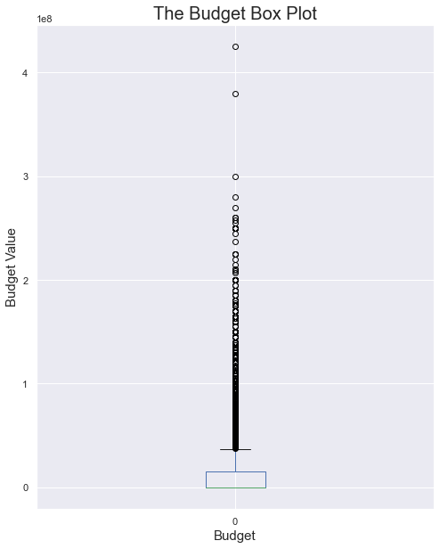

```python
fig, ax = plt.subplots(figsize=(10, 6))
df.budget.plot(kind='box', figsize=(8, 10), use_index=False);
plt.xlabel('Budget', fontsize=15);
plt.ylabel('Budget Value', fontsize=15);
plt.title('The Budget Box Plot', fontsize=20);
```

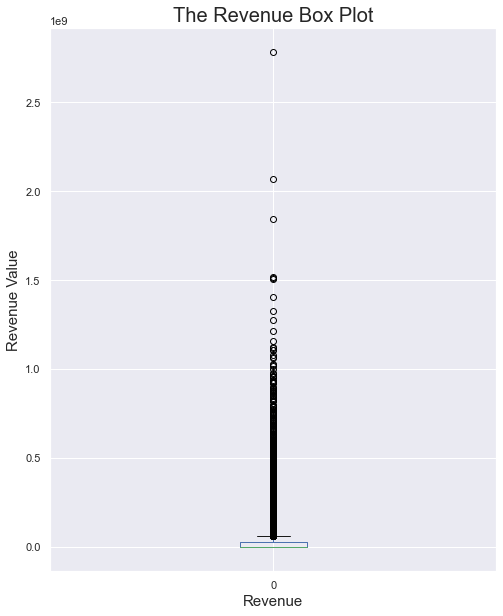

```python
df.revenue.plot(kind='box', figsize=(8, 10), use_index=False);
plt.xlabel('Revenue', fontsize=15);
plt.ylabel('Revenue Value', fontsize=15);
plt.title('The Revenue Box Plot', fontsize=20);
```

There are indeed many outliers.

### Data Cleaning and New Dataframe Creation

Due to the data's great amount of outliers, missing values, and zero values, it is difficult to get valid analysis results. Therefore, in this section, we need to find ways to resolve these issues. While we are cleaning the data, further exploration is also undertaken. As we move along, several versions of the data will be created and saved at each improvement.

First, convert the data type of release_date from strings to datetime.

```python
df.release_date = pd.to_datetime(df.release_date, format='%m/%d/%y')
df.info()
```

```
<class 'pandas.core.frame.DataFrame'>
RangeIndex: 10866 entries, 0 to 10865
Data columns (total 21 columns):
 #   Column                Non-Null Count  Dtype
---  ------                --------------  -----
 0   id                    10866 non-null  int64
 1   imdb_id               10856 non-null  object
 2   popularity            10866 non-null  float64
 3   budget                10866 non-null  int64
 4   revenue               10866 non-null  int64
 5   original_title        10866 non-null  object
 6   cast                  10790 non-null  object
 7   homepage              2936 non-null   object
 8   director              10822 non-null  object
 9   tagline               8042 non-null   object
 10  keywords              9373 non-null   object
 11  overview              10862 non-null  object
 12  runtime               10866 non-null  int64
 13  genres                10843 non-null  object
 14  production_companies  9836 non-null   object
 15  release_date          10866 non-null  datetime64[ns]
 16  vote_count            10866 non-null  int64
 17  vote_average          10866 non-null  float64
 18  release_year          10866 non-null  int64
 19  budget_adj            10866 non-null  float64
 20  revenue_adj           10866 non-null  float64
dtypes: datetime64[ns](1), float64(4), int64(6), object(10)
memory usage: 1.7+ MB
```

Drop the duplicate rows and see if the change works.

```python
# drop the duplicates
df.drop_duplicates(inplace=True);
df.shape
```

```
(10865, 21)
```

Remove the unnecessary columns and check if that works.

```python
df.drop(['homepage', 'imdb_id', 'budget_adj', 'revenue_adj'], axis=1, inplace=True)
df.shape
```

```
(10865, 17)
```

Take a look at the number of missing values.

```python
df.isnull().sum()
```

```
id                         0
popularity                 0
budget                     0
revenue                    0
original_title             0
cast                      76
director                  44
tagline                 2824
keywords                1493
overview                   4
runtime                    0
genres                    23
production_companies    1030
release_date               0
vote_count                 0
vote_average               0
release_year               0
dtype: int64
```

Drop the rows that have a few missing values so as to make minimal change to the data, and check the result.

```python
df.dropna(subset=['cast', 'director', 'overview', 'genres'], axis=0, inplace=True)
df.shape
```

```
(10729, 17)
```

```python
df.isnull().sum()
```

```
id                         0
popularity                 0
budget                     0
revenue                    0
original_title             0
cast                       0
director                   0
tagline                 2728
keywords                1424
overview                   0
runtime                    0
genres                     0
production_companies     957
release_date               0
vote_count                 0
vote_average               0
release_year               0
dtype: int64
```

As we saw above, those rows have been dropped.

Since now all the missing values are of type strings, after some consideration, we can choose to keep all the columns rather than dropping them (there are many rows to drop). Thus we can choose to fill the missing values with Not Available strings - "N/A", and check if all the missing values are resolved, as shown below.

```python
df.fillna("N/A", inplace=True)
df.isnull().sum()
```

```
id                      0
popularity              0
budget                  0
revenue                 0
original_title          0
cast                    0
director                0
tagline                 0
keywords                0
overview                0
runtime                 0
genres                  0
production_companies    0
release_date            0
vote_count              0
vote_average            0
release_year            0
dtype: int64
```

Now we have successfully removed all the missing values. We can save the first version of the data called clean_v1.csv and assign df to a new name df_v1.

```python
df.to_csv('clean_v1.csv', index=False)
df_v1 = df
```

Next, we can remove the outliers. First, filter out the rows that are zero budget and zero revenue from df_v1 and assign it to df1 as shown below.

```python
df1 = df_v1[((df_v1.budget != 0) & (df_v1.revenue != 0))]
```

Check the size of df_v1.

```python
df_v1.shape
```

```
(10729, 17)
```

Check the size of df1. About 7000 data filtered out.

```python
df1.shape
```

```
(3849, 17)
```

Take a look at the minimum values and the maximum values.

```python
df1.revenue.min(), df1.revenue.max()
```

```
(2, 2781505847)
```

```python
df1.budget.min(), df1.budget.max()
```

```
(1, 425000000)
```

Based on observation from the above, it is necessary to remove the outliers. Either budget or revenue will do the work. We will choose the process based on revenue. However, both analyses are included below. In either analyis, its interquartile range (IQR) is first calculated and then the outliers are removed. We verify this by showing its summary statistics.

```python
# calculate the interquartile range
budget_Q1 = df1.budget.quantile(0.25)
budget_Q3 = df1.budget.quantile(0.75)
budget_IQR = budget_Q3 - budget_Q1
```

```python
# remove outliers and show summary statistics
df1[df1.budget.between(budget_Q1 - 1.5 * budget_IQR, budget_Q3 + 1.5 * budget_IQR )].describe()
```

|  | id | popularity | budget | revenue | runtime | vote_count | vote_average | release_year |
| --- | --- | --- | --- | --- | --- | --- | --- | --- |
| count | 3605.000000 | 3605.000000 | 3.605000e+03 | 3.605000e+03 | 3605.000000 | 3605.000000 | 3605.000000 | 3605.000000 |
| mean | 39610.399445 | 1.040658 | 2.883394e+07 | 8.083865e+07 | 108.352566 | 416.627184 | 6.156172 | 2000.764771 |
| std | 67786.683580 | 1.024694 | 2.565575e+07 | 1.140187e+08 | 19.394517 | 655.466194 | 0.796346 | 11.424710 |
| min | 5.000000 | 0.001117 | 1.000000e+00 | 2.000000e+00 | 15.000000 | 10.000000 | 2.200000 | 1960.000000 |
| 25% | 6415.000000 | 0.446458 | 9.000000e+06 | 1.231465e+07 | 95.000000 | 65.000000 | 5.600000 | 1995.000000 |
| 50% | 11260.000000 | 0.761779 | 2.000000e+07 | 3.967316e+07 | 105.000000 | 182.000000 | 6.200000 | 2004.000000 |
| 75% | 37094.000000 | 1.261132 | 4.000000e+07 | 1.043842e+08 | 118.000000 | 480.000000 | 6.700000 | 2010.000000 |
| max | 343795.000000 | 13.112507 | 1.100000e+08 | 1.156731e+09 | 338.000000 | 7375.000000 | 8.400000 | 2015.000000 |

```python
# calculate the interquartile range
revenue_Q1 = df1.revenue.quantile(0.25)
revenue_Q3 = df1.revenue.quantile(0.75)
revenue_IQR = revenue_Q3 - revenue_Q1
```

```python
# remove outliers and show summary statistics
df1[df1.revenue.between(revenue_Q1 - 1.5 * revenue_IQR, revenue_Q3 + 1.5 * revenue_IQR )].describe()
```

|  | id | popularity | budget | revenue | runtime | vote_count | vote_average | release_year |
| --- | --- | --- | --- | --- | --- | --- | --- | --- |
| count | 3488.00000 | 3488.000000 | 3.488000e+03 | 3.488000e+03 | 3488.000000 | 3488.000000 | 3488.00000 | 3488.000000 |
| mean | 39908.03555 | 0.963265 | 2.955281e+07 | 6.313863e+07 | 108.085722 | 352.793291 | 6.12047 | 2000.878727 |
| std | 67533.57685 | 0.862605 | 3.022774e+07 | 6.768503e+07 | 19.208584 | 498.285808 | 0.78850 | 11.446785 |
| min | 5.00000 | 0.001117 | 1.000000e+00 | 2.000000e+00 | 15.000000 | 10.000000 | 2.20000 | 1960.000000 |
| 25% | 7452.50000 | 0.437509 | 8.469200e+06 | 1.163669e+07 | 95.000000 | 63.000000 | 5.60000 | 1995.000000 |
| 50% | 11389.50000 | 0.740338 | 2.000000e+07 | 3.701800e+07 | 105.000000 | 173.000000 | 6.20000 | 2004.000000 |
| 75% | 37824.25000 | 1.203930 | 4.000000e+07 | 9.549851e+07 | 117.000000 | 427.000000 | 6.70000 | 2010.000000 |
| max | 343795.00000 | 11.422751 | 4.250000e+08 | 2.898474e+08 | 338.000000 | 5923.000000 | 8.40000 | 2015.000000 |

Assign the new data to df_profit.

```python
df_profit = df1[df1.revenue.between(revenue_Q1 - 1.5 * revenue_IQR, revenue_Q3 + 1.5 * revenue_IQR )]
```

Check how much data remains. Another ~400 data filtered out.

```python
df_profit.shape
```

```
(3488, 17)
```

From the table above, everything looks fine. We can then assign our second version to df_profit, and save it to a csv file called clean_profit.csv. This dataframe will be used for profit related analysis.

```python
df_profit.to_csv('clean_profit.csv', index=False)
```

Next, in order to perform analysis related to cast, we need to parse the cast column, which is multivalue. We then need to split them into multiple rows - one with the value for the first name, and the other with the value for the second name and so on - so that it is single-valued. For example, if we have 3 actors/actresses in a cast cell, we need to create 3 duplicated rows and replace each cell with their distinct actor/actress. In order to keep all the cast in the data, we need to parse the column from df_v1, rather than from df_profit. We make a copy of df_v1 called df_cast for this cleaning process.

```python
df_i = df_v1.copy()                 # make a copy for iteration
df_cast = df_v1                     # make a copy from df_v1 for processing
df_old_index = []                   # the index for dropping the rows
j = df_i.columns.get_loc('cast')    # get the index position of column cast
for i, cast in enumerate(df_i.cast):
    cast_list = cast.strip().split('|')   # create a list of actors/actresses
    n_cast = len(cast_list)               # get the length of the list
#     print(n_cast)                       # print number of actors/actresses in each cast cell
    new_rows = df_i.iloc[[i]].copy()      # make a copy of row to be parsed
    if n_cast > 1:
        df_old_index.append(i)
        new_rows = new_rows.append([new_rows]*(n_cast - 1))    # duplicate number of rows based on the list length, so a new dataframe is created with <n_cast> duplicated rows called new_rows
        for k, each in enumerate(cast_list):
            new_rows.iat[k, j] = each                          # replace the value at each cast cell
        df_cast = df_cast.append(new_rows, ignore_index=True)  # append the new_rows to the end the original dataframe df_v1

df_cast.drop(index=df_old_index, inplace=True)                 # drop those with multivalued cast rows
```

Validate the result and check the dataframe dimensions.

```python
df_cast.cast.str.contains("|", regex=False).sum()
```

```
0
```

```python
df_cast.shape
```

```
(52324, 17)
```

The dataframe expands about 5 times, which is expected since most of the cast cells has 4 or 5 actors/actresses. This can be verified from printing n_cast from above. Save this version to a csv file called clean_cast.csv.

```python
df_cast.to_csv('clean_cast.csv', index=False)
```

Now the cast parsing has done. We are now able to use that dataframe to do the next cleaning process. Even though the cast has parsed, this data still has many outliers. If we would like to perform analysis related to cast and revenue, it would be biased. Therefore, the same outlier-removing procedure is needed on df_cast dataframe.

First, check df_cast's summary statistics.

```python
# df_cast = pd.read_csv('clean_cast.csv')
df_cast.describe()
```

|  | id | popularity | budget | revenue | runtime | vote_count | vote_average | release_year |
| --- | --- | --- | --- | --- | --- | --- | --- | --- |
| count | 52324.000000 | 52324.000000 | 5.232400e+04 | 5.232400e+04 | 52324.000000 | 52324.000000 | 52324.000000 | 52324.000000 |
| mean | 63947.454763 | 0.663440 | 1.516979e+07 | 4.133458e+07 | 102.964739 | 224.598540 | 5.949746 | 2001.108765 |
| std | 90572.099505 | 1.013761 | 3.136790e+07 | 1.189596e+08 | 28.874062 | 585.268973 | 0.922930 | 12.868184 |
| min | 5.000000 | 0.000188 | 0.000000e+00 | 0.000000e+00 | 0.000000 | 10.000000 | 1.500000 | 1960.000000 |
| 25% | 10448.000000 | 0.217023 | 0.000000e+00 | 0.000000e+00 | 90.000000 | 17.000000 | 5.400000 | 1994.000000 |
| 50% | 19611.000000 | 0.394271 | 0.000000e+00 | 0.000000e+00 | 99.000000 | 40.000000 | 6.000000 | 2005.000000 |
| 75% | 71866.000000 | 0.733947 | 1.700000e+07 | 2.682064e+07 | 112.000000 | 154.000000 | 6.600000 | 2011.000000 |
| max | 417859.000000 | 32.985763 | 4.250000e+08 | 2.781506e+09 | 900.000000 | 9767.000000 | 9.200000 | 2015.000000 |

Remove outliers.

```python
df_tmp = df_cast[((df_cast.budget != 0) & (df_cast.revenue != 0))]
revenue_Q1c = df_tmp.revenue.quantile(0.25)
revenue_Q3c = df_tmp.revenue.quantile(0.75)
revenue_IQRc = revenue_Q3c - revenue_Q1c
```

The resulted dataframe is called df_revenue.

```python
df_revenue = df_tmp[df_tmp.revenue.between(revenue_Q1c - 1.5 * revenue_IQRc, revenue_Q3c + 1.5 * revenue_IQRc )]
```

Check the size. 2/3 of data is filtered.

```python
df_revenue.shape
```

```
(17386, 17)
```

Save it to a local file.

```python
df_revenue.to_csv('clean_revenue.csv', index=False)
```

## Exploratory Data Analysis

We have now cleaned and generated 4 different dataframes - df_v1, df_profit, df_cast, and df_revenue - for different purposes. Thus, we are ready to perform exploratory data analysis. There are five research questions that need to be addressed as listed here:

1. Who are the most popular 50 actors/actresses?
2. Which genres are most popular?
3. Which month released the most movies?
4. Is budget correlated with revenue?
5. What are the features related to high revenue?

And the EDA will be conducted in this order.

First of all, we reload the data set (if needed). And since df_v1's release_date column is of type string every time the data set is reloaded from files, we need to revert it to datetime. Only this dataframe needs to be reverted since it does not matter to other dataframes.

```python
df_v1 = pd.read_csv('clean_v1.csv')
df_profit = pd.read_csv('clean_profit.csv')
df_cast = pd.read_csv('clean_cast.csv')
df_revenue = pd.read_csv('clean_revenue.csv')

# This dataframe's release_date column needs to be converted to datetime for the analysis if loaed from here
df_v1.release_date = pd.to_datetime(df_v1.release_date, format='%Y-%m-%d')
```

### 1. Who are the most popular 50 actors/actresses?

It is best to use df_cast dataframe for this analysis. Since the cast has been parsed, it is suitable to use groupby to perform aggregation. As a result, the popularity rating is based on the number of movies he/she has acted in.

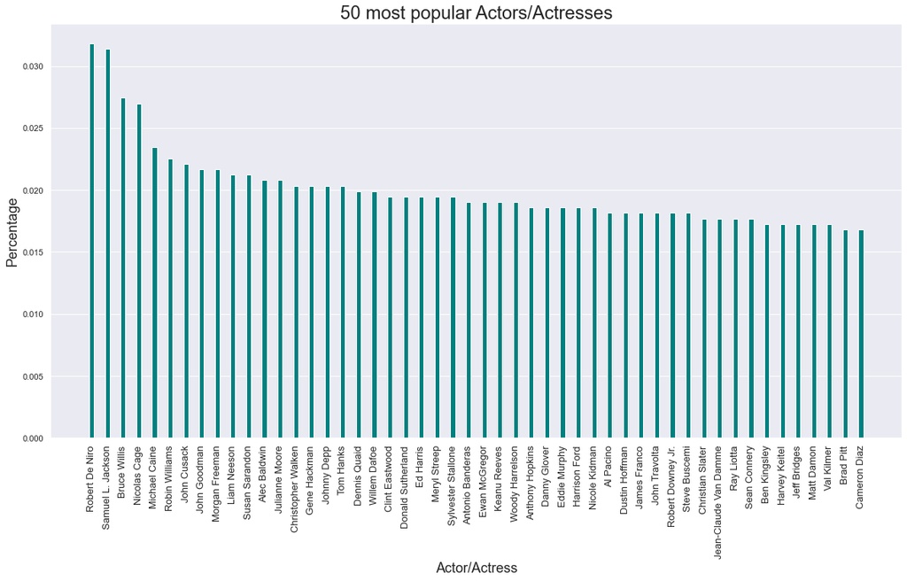

```python
total = df_cast.groupby('cast').size().nlargest(50).sum()   # find total count of most popular 50 actorr/actresses
most_popular = df_cast.groupby('cast').size().nlargest(50)  # find count of each popular actor/actress
proportion = most_popular / total                           # get the proportion

# plot the figure and tune up its settings
fig, ax = plt.subplots(figsize=(20, 10));
plt.bar(most_popular.index, height=proportion, width=0.3, animated=True, color='teal');
plt.xticks(rotation=90, fontsize=13);
plt.grid(which='major', axis='x');
plt.xlabel('Actor/Actress', fontsize=18);
plt.ylabel('Percentage', fontsize=18);
plt.title('50 most popular Actors/Actresses', fontsize=24);
```

Here are the 50 most popoular actors/actresses. The results were as expected since these people are celebrities, so their names are more familiar. In addition, some are still alive and active in the movie industry.

### 2. Which genres are most popular?

First, we need to know how many genres are in this data set. The best dataframe we can choose from is df_v1 since it retains most of the information about genres. We can parse the column genres and obtain 20 genres as listed below.

```python
genres = []
for each in df_v1.genres:                   # iterate through the column genres
    genres.extend(each.strip().split('|'))  # make a list of genres
genres = set(genres)                        # get unique genres from the list
len(genres), genres
```

```
(20,
 {'Action',
  'Adventure',
  'Animation',
  'Comedy',
  'Crime',
  'Documentary',
  'Drama',
  'Family',
  'Fantasy',
  'Foreign',
  'History',
  'Horror',
  'Music',
  'Mystery',
  'Romance',
  'Science Fiction',
  'TV Movie',
  'Thriller',
  'War',
  'Western'})
```

A defaul dictionary is used to calculate the number of movies in each genre. The result is shown below.

```python
from collections import defaultdict   # import defaultdict from collections module

genres_count = defaultdict(int)       # create an object of defaultdict of type int
for genre in genres:                  # iterate through the set we just created above
    for genre_str in df_v1.genres:    # iterate through column genres
        if genre in genre_str:
            genres_count[genre] += 1  # increment the count the genre is in genre_str

genres_count
```

```
defaultdict(int,
            {'Fantasy': 908,
             'TV Movie': 162,
             'Adventure': 1465,
             'Romance': 1707,
             'Animation': 664,
             'History': 330,
             'Action': 2376,
             'Horror': 1636,
             'Western': 164,
             'Family': 1214,
             'Foreign': 184,
             'Thriller': 2902,
             'War': 268,
             'Music': 398,
             'Comedy': 3774,
             'Mystery': 808,
             'Documentary': 470,
             'Drama': 4746,
             'Science Fiction': 1221,
             'Crime': 1353})
```

The total count is expected to be larger than the total number of rows in the df_v1 since each movie can be in multiple genres. df_v1 has 10,729 rows, and total genres_count is 26,750 as shown below.

```python
df_v1.shape
```

```
(10729, 17)
```

```python
sum(genres_count.values())
```

```
26750
```

Now we can use the obtained result to plot a bar graph. We can calculate the total count, find its proportion for each genre, then plot and tweek its settings as shown below.

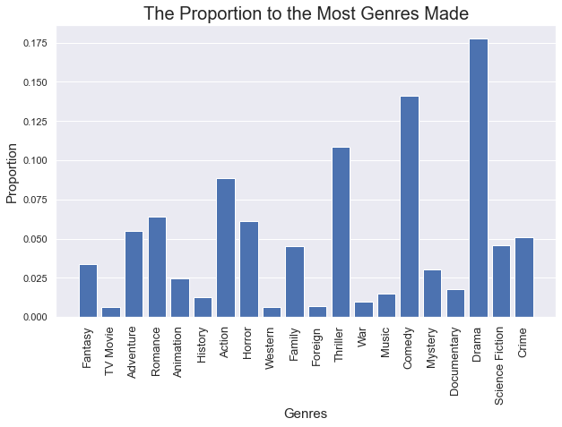

```python
total = sum(genres_count.values())
proportion = np.array(list(genres_count.values())) / total

# Plot the bar graph and configure the settings
fig, ax = plt.subplots(figsize=(10, 6));
plt.bar(genres_count.keys(), proportion);
plt.xticks(rotation=90, fontsize=13);
plt.grid(which='major', axis='x');
plt.xlabel('Genres', fontsize=15);
plt.ylabel('Proportion', fontsize=15);
plt.title('The Proportion to the Most Genres Made', fontsize=20);
```

According to the graph, the most genres made throughout these years is Drama.

### 3. Which month released the most movies?

To answer this question, we can add a new column release_month to df_v1 containing only month values (integer). This information is extracted from the column release_date. Then, we create a histogram to sum up the count of movies released each month.

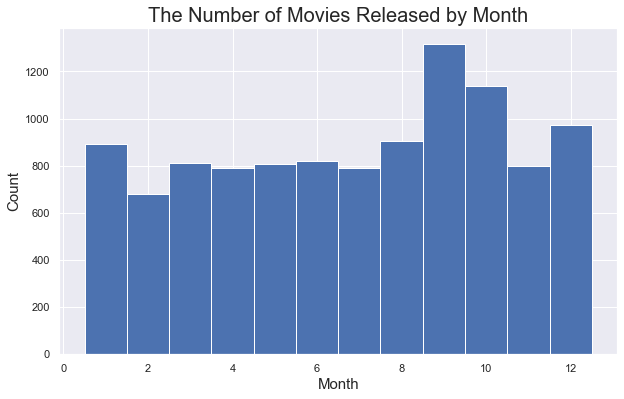

```python
month = [day.month for day in df_v1.release_date]   # make a list of month extracted from df_v1
df_v1['release_month'] = month                      # add a new column

# create a histogram
fig, ax = plt.subplots(figsize=(10, 6))
ax.hist(df_v1.release_month, bins=[1,2,3,4,5,6,7,8,9,10,11,12,13], align='left');
plt.xlabel('Month', fontsize=15);
plt.ylabel('Count', fontsize=15);
plt.title('The Number of Movies Released by Month', fontsize=20);
```

According to the graph above, production companies released the most movies in September.

### 4. Is budget correlated with revenue?

To address this question, we can use df_profit since the outliers of revenue are removed. To visualize the correlation, we can first create a scatter plot with a regression line, using seaborn regplot. Then to quantify the findings, we can calcuate the correlation coefficient and its respective p-value using scipy library.

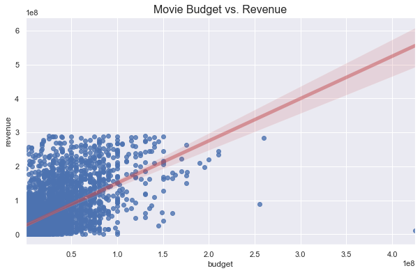

```python
# create a scatter plot between budget and revenue
fig, ax = plt.subplots(figsize=(10, 6))
sns.regplot(x=df_profit['budget'], y=df_profit['revenue'], line_kws={"color":"r","alpha":0.5,"lw":5});
plt.title('Movie Budget vs. Revenue', fontsize=16);
```

Calculate the correlation coefficient and the p-value.

```python
# calculated the correlation coefficient and p-value
from scipy.stats import pearsonr
pearsonr(df_profit.budget, df_profit.revenue)
```

```
(0.5559580159768496, 3.1463889328433116e-282)
```

According to the plot and calculations above, the correlation coefficient is 0.56, and the p-value is almost 0. We can conclude that there is a statistically significant correlation between budget and revenue.

### 5. What are the features related to high revenue?

The best dataframe to use is df_revenue since this dataframe's cast has been parsed and the outliers has been trimmed. We first look at the summary statistics of this table. Then we can take a look at the correlation between all the numeric columns. Finally, we can explore the correlation between revenue and the two categorical columns cast and directors.

Look at the summary statistics of df_revenue.

```python
df_revenue.describe()
```

|  | id | popularity | budget | revenue | runtime | vote_count | vote_average | release_year |
| --- | --- | --- | --- | --- | --- | --- | --- | --- |
| count | 17386.000000 | 17386.000000 | 1.738600e+04 | 1.738600e+04 | 17386.000000 | 17386.000000 | 17386.000000 | 17386.000000 |
| mean | 39839.175774 | 0.964945 | 2.963129e+07 | 6.331684e+07 | 108.119809 | 353.606810 | 6.119245 | 2000.860290 |
| std | 67500.481542 | 0.863130 | 3.023671e+07 | 6.770277e+07 | 19.185946 | 498.734753 | 0.787668 | 11.451735 |
| min | 5.000000 | 0.001117 | 1.000000e+00 | 2.000000e+00 | 15.000000 | 10.000000 | 2.200000 | 1960.000000 |
| 25% | 7446.000000 | 0.438475 | 8.500000e+06 | 1.183822e+07 | 95.000000 | 63.000000 | 5.600000 | 1995.000000 |
| 50% | 11371.000000 | 0.742001 | 2.000000e+07 | 3.730356e+07 | 105.000000 | 174.000000 | 6.200000 | 2004.000000 |
| 75% | 37786.000000 | 1.204640 | 4.000000e+07 | 9.569700e+07 | 117.000000 | 428.000000 | 6.700000 | 2010.000000 |
| max | 343795.000000 | 11.422751 | 4.250000e+08 | 2.898474e+08 | 338.000000 | 5923.000000 | 8.400000 | 2015.000000 |

Find all the correlation coefficients of the numeric values from df_revenue.

```python
df_revenue.corr()
```

|  | id | popularity | budget | revenue | runtime | vote_count | vote_average | release_year |
| --- | --- | --- | --- | --- | --- | --- | --- | --- |
| id | 1.000000 | 0.235025 | -0.064056 | -0.040462 | -0.032723 | 0.164530 | -0.009270 | 0.488988 |
| popularity | 0.235025 | 1.000000 | 0.268806 | 0.473121 | 0.141172 | 0.796734 | 0.298761 | 0.155946 |
| budget | -0.064056 | 0.268806 | 1.000000 | 0.555958 | 0.195433 | 0.306293 | -0.114956 | 0.224944 |
| revenue | -0.040462 | 0.473121 | 0.555958 | 1.000000 | 0.166888 | 0.532286 | 0.121100 | 0.087360 |
| runtime | -0.032723 | 0.141172 | 0.195433 | 0.166888 | 1.000000 | 0.173145 | 0.331806 | -0.146000 |
| vote_count | 0.164530 | 0.796734 | 0.306293 | 0.532286 | 0.173145 | 1.000000 | 0.359491 | 0.192270 |
| vote_average | -0.009270 | 0.298761 | -0.114956 | 0.121100 | 0.331806 | 0.359491 | 1.000000 | -0.161775 |
| release_year | 0.488988 | 0.155946 | 0.224944 | 0.087360 | -0.146000 | 0.192270 | -0.161775 | 1.000000 |

From the tables above, the budget is the strongest factor among all the numeric features (which is aligned with the previous analysis), then vote_count and popularity are also related features, as expected. However, the vote_average is not as correlated as expected, so there might be outliers in vote_average. To verify, we can create a box plot.

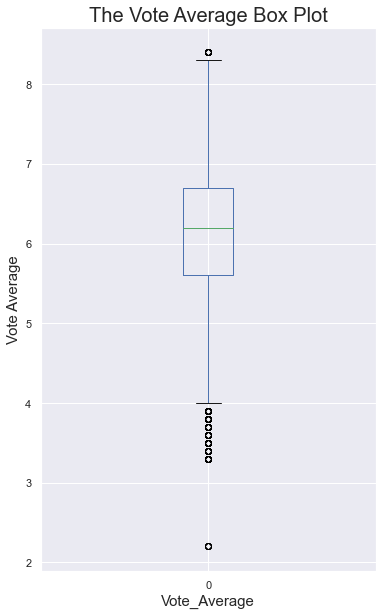

```python
fig, ax = plt.subplots(figsize=(6, 10));
df_revenue.vote_average.plot(kind='box', use_index=False);
plt.xlabel('Vote_Average', fontsize=15);
plt.ylabel('Vote Average', fontsize=15);
plt.title('The Vote Average Box Plot', fontsize=20);
```

The box plot above proves the concern that vote_average also has many outliers.

Next, we can create a scatter plot of actors/actresses popularity and their average revenue. Then, the correlation coefficient and the p-value can be calculated to quantify the result.

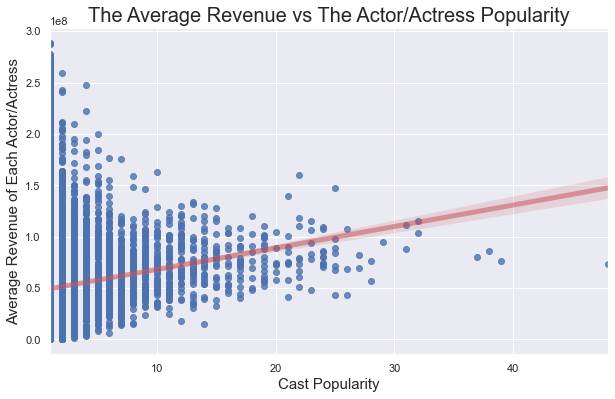

```python
cast_rating = df_revenue.groupby('cast').size()
revenue_cast = df_revenue.groupby('cast').mean()['revenue']

fig, ax = plt.subplots(figsize=(10, 6))
sns.regplot(x=cast_rating, y=revenue_cast, line_kws={"color":"r","alpha":0.5,"lw":5});
plt.xlabel('Cast Popularity', fontsize=15);
plt.ylabel('Average Revenue of Each Actor/Actress', fontsize=15);
plt.title('The Average Revenue vs The Actor/Actress Popularity', fontsize=20);
```

Calculate the correlation coefficient and the p-value.

```python
from scipy.stats import pearsonr
pearsonr(cast_rating, revenue_cast)
```

```
(0.1443443383542723, 2.7371020760803317e-32)
```

Based on the analysis above, there is also a positive correlation between cast and revenue, and the result is statistically significant even though the correlation coefficient is merely 0.144.

We can repeat the process for the directors.

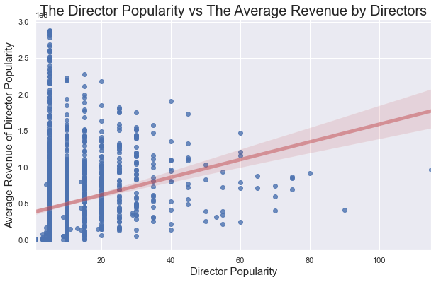

```python
director_rating = df_revenue.groupby(by='director').size()
revenue_director = df_revenue.groupby('director').mean()['revenue']

fig, ax = plt.subplots(figsize=(10, 6))
sns.regplot(x=director_rating, y=revenue_director, line_kws={"color":"r","alpha":0.5,"lw":5});
plt.xlabel('Director Popularity', fontsize=15);
plt.ylabel('Average Revenue of Director Popularity', fontsize=15);
plt.title('The Director Popularity vs The Average Revenue by Directors', fontsize=20);
```

Calculate the correlation coefficient and the p-value.

```python
from scipy.stats import pearsonr
pearsonr(director_rating, revenue_director)
```

```
(0.23427780275241183, 5.857839654210982e-22)
```

Based on the analysis above, there is also a positive correlation between director and revenue, and the result is also statistically significant. The correlation coefficient is 0.234, which is higher than that of the cast.

## Recommendation

There are still many research questions unanswered. The research process and the questions can also be further refined. Such questions are, for example, "which production company produces most genres?", or "which genre is most popular by year?". In the report, we chose to filter out the 0 values of both budget and revenue, resulting in a great amount data lost. A better result may be acquired by filtering out the 0 values of one variable at a time, particularly the variable revenue. And the vote_average may also be a feature correlated to revenue as long as the outlier-removing process has been done based on this variable.